# ML_project

Oz Solomon

Oct 3, 2020

**Loading and cleaning the data**  
############################################

```r
library(caret);
```

```r
library(rpart);
library(pheatmap)
library(ggplot2)
#install.packages("corrplot")
library(corrplot)
library(pROC) # for AUC calculations
library(PRROC) # for Precision-Recall curve calculations

set<-read.csv("/home/oz/Downloads/pml-training.csv",header=T,row.names = 1);


## Counts how much NAs you have in a column
count_NA<-function(v){
  k=0;
  for(i in 1:length(v)){
    if(is.na(v[i])){
      k=k+1;
    }
  }

  return(k);
}


### Find how much NAs you have ##

val<-apply(set,2, count_NA);

len<-nrow(set)

## Filtering-out the variables with too much NAs (>90% NAs) from downstream analysis #
col_to_ignore<-names(val[val>len*0.9])

set2<-set[,!(colnames(set)%in%col_to_ignore)]

set3<-set2

summary(set3)
```

```
##   user_name         raw_timestamp_part_1 raw_timestamp_part_2
##  Length:19622       Min.   :1.322e+09    Min.   :   294
##  Class :character   1st Qu.:1.323e+09    1st Qu.:252912
##  Mode  :character   Median :1.323e+09    Median :496380
##                     Mean   :1.323e+09    Mean   :500656
##                     3rd Qu.:1.323e+09    3rd Qu.:751891
##                     Max.   :1.323e+09    Max.   :998801
##  cvtd_timestamp      new_window          num_window      roll_belt
##  Length:19622       Length:19622       Min.   :  1.0   Min.   :-28.90
##  Class :character   Class :character   1st Qu.:222.0   1st Qu.:  1.10
##  Mode  :character   Mode  :character   Median :424.0   Median :113.00
##                                        Mean   :430.6   Mean   : 64.41
##                                        3rd Qu.:644.0   3rd Qu.:123.00
##                                        Max.   :864.0   Max.   :162.00
##    pitch_belt          yaw_belt       total_accel_belt kurtosis_roll_belt
##  Min.   :-55.8000   Min.   :-180.00   Min.   : 0.00    Length:19622
##  1st Qu.:  1.7600   1st Qu.: -88.30   1st Qu.: 3.00    Class :character
##  Median :  5.2800   Median : -13.00   Median :17.00    Mode  :character
##  Mean   :  0.3053   Mean   : -11.21   Mean   :11.31
##  3rd Qu.: 14.9000   3rd Qu.:  12.90   3rd Qu.:18.00
##  Max.   : 60.3000   Max.   : 179.00   Max.   :29.00
##  kurtosis_picth_belt kurtosis_yaw_belt  skewness_roll_belt skewness_roll_belt.1
##  Length:19622        Length:19622       Length:19622       Length:19622
##  Class :character    Class :character   Class :character   Class :character
##  Mode  :character    Mode  :character   Mode  :character   Mode  :character
##
##
##
##  skewness_yaw_belt  max_yaw_belt       min_yaw_belt       amplitude_yaw_belt
##  Length:19622       Length:19622       Length:19622       Length:19622
##  Class :character   Class :character   Class :character   Class :character
##  Mode  :character   Mode  :character   Mode  :character   Mode  :character
##
##
##
##   gyros_belt_x        gyros_belt_y       gyros_belt_z      accel_belt_x
##  Min.   :-1.040000   Min.   :-0.64000   Min.   :-1.4600   Min.   :-120.000
##  1st Qu.:-0.030000   1st Qu.: 0.00000   1st Qu.:-0.2000   1st Qu.: -21.000
##  Median : 0.030000   Median : 0.02000   Median :-0.1000   Median : -15.000
##  Mean   :-0.005592   Mean   : 0.03959   Mean   :-0.1305   Mean   :  -5.595
```

[output cut: 120 more lines]

```
##  Max.   :108.00      Max.   :  3.970   Max.   :311.00000   Max.   :231.0000
##  accel_forearm_x   accel_forearm_y  accel_forearm_z   magnet_forearm_x
##  Min.   :-498.00   Min.   :-632.0   Min.   :-446.00   Min.   :-1280.0
##  1st Qu.:-178.00   1st Qu.:  57.0   1st Qu.:-182.00   1st Qu.: -616.0
##  Median : -57.00   Median : 201.0   Median : -39.00   Median : -378.0
##  Mean   : -61.65   Mean   : 163.7   Mean   : -55.29   Mean   : -312.6
##  3rd Qu.:  76.00   3rd Qu.: 312.0   3rd Qu.:  26.00   3rd Qu.:  -73.0
##  Max.   : 477.00   Max.   : 923.0   Max.   : 291.00   Max.   :  672.0
##  magnet_forearm_y magnet_forearm_z    classe
##  Min.   :-896.0   Min.   :-973.0   Length:19622
##  1st Qu.:   2.0   1st Qu.: 191.0   Class :character
##  Median : 591.0   Median : 511.0   Mode  :character
##  Mean   : 380.1   Mean   : 393.6
##  3rd Qu.: 737.0   3rd Qu.: 653.0
##  Max.   :1480.0   Max.   :1090.0
```

Examine variables with too few levels  
- variables with too much empty values.  
- Covert them to NA and filter-out columns with >90% NAs (as in previous step).  
###############################

```r
vars_to_examine<-c()
k=1;

for(i in 1:ncol(set3)){
  len_s<-length(unique(set3[,i]))
  if(len_s<3){
    vars_to_examine[k]<-colnames(set3)[i]
    k=k+1;
  }
}

print(vars_to_examine)
```

```
## [1] "new_window"            "kurtosis_yaw_belt"     "skewness_yaw_belt"
## [4] "kurtosis_yaw_dumbbell" "skewness_yaw_dumbbell" "kurtosis_yaw_forearm"
## [7] "skewness_yaw_forearm"
```

```r
## expet "new_window" all the vars in vars to examine have errors and empty values -> so we remove them.



vars_to_ignore<-vars_to_examine[(vars_to_examine)!="new_window"]

for(j in 1:ncol(set3)){
  for(i in 1:nrow(set3)){
    if(set3[i,j]==""){
      set3[i,j]=NA;
    }
  }
}

len<-nrow(set3)
val<-apply(set3,2, count_NA);
col_to_ignore<-names(val[val>len*0.9])
set3<-set3[,!(colnames(set3)%in%col_to_ignore)]

summary(set3)
```

```
##   user_name         raw_timestamp_part_1 raw_timestamp_part_2
##  Length:19622       Min.   :1.322e+09    Min.   :   294
##  Class :character   1st Qu.:1.323e+09    1st Qu.:252912
##  Mode  :character   Median :1.323e+09    Median :496380
##                     Mean   :1.323e+09    Mean   :500656
##                     3rd Qu.:1.323e+09    3rd Qu.:751891
##                     Max.   :1.323e+09    Max.   :998801
##  cvtd_timestamp      new_window          num_window      roll_belt
##  Length:19622       Length:19622       Min.   :  1.0   Min.   :-28.90
##  Class :character   Class :character   1st Qu.:222.0   1st Qu.:  1.10
##  Mode  :character   Mode  :character   Median :424.0   Median :113.00
##                                        Mean   :430.6   Mean   : 64.41
##                                        3rd Qu.:644.0   3rd Qu.:123.00
##                                        Max.   :864.0   Max.   :162.00
##    pitch_belt          yaw_belt       total_accel_belt  gyros_belt_x
##  Min.   :-55.8000   Min.   :-180.00   Min.   : 0.00    Min.   :-1.040000
##  1st Qu.:  1.7600   1st Qu.: -88.30   1st Qu.: 3.00    1st Qu.:-0.030000
##  Median :  5.2800   Median : -13.00   Median :17.00    Median : 0.030000
##  Mean   :  0.3053   Mean   : -11.21   Mean   :11.31    Mean   :-0.005592
##  3rd Qu.: 14.9000   3rd Qu.:  12.90   3rd Qu.:18.00    3rd Qu.: 0.110000
##  Max.   : 60.3000   Max.   : 179.00   Max.   :29.00    Max.   : 2.220000
##   gyros_belt_y       gyros_belt_z      accel_belt_x       accel_belt_y
##  Min.   :-0.64000   Min.   :-1.4600   Min.   :-120.000   Min.   :-69.00
##  1st Qu.: 0.00000   1st Qu.:-0.2000   1st Qu.: -21.000   1st Qu.:  3.00
##  Median : 0.02000   Median :-0.1000   Median : -15.000   Median : 35.00
##  Mean   : 0.03959   Mean   :-0.1305   Mean   :  -5.595   Mean   : 30.15
##  3rd Qu.: 0.11000   3rd Qu.:-0.0200   3rd Qu.:  -5.000   3rd Qu.: 61.00
##  Max.   : 0.64000   Max.   : 1.6200   Max.   :  85.000   Max.   :164.00
##   accel_belt_z     magnet_belt_x   magnet_belt_y   magnet_belt_z
##  Min.   :-275.00   Min.   :-52.0   Min.   :354.0   Min.   :-623.0
##  1st Qu.:-162.00   1st Qu.:  9.0   1st Qu.:581.0   1st Qu.:-375.0
##  Median :-152.00   Median : 35.0   Median :601.0   Median :-320.0
##  Mean   : -72.59   Mean   : 55.6   Mean   :593.7   Mean   :-345.5
##  3rd Qu.:  27.00   3rd Qu.: 59.0   3rd Qu.:610.0   3rd Qu.:-306.0
##  Max.   : 105.00   Max.   :485.0   Max.   :673.0   Max.   : 293.0
##     roll_arm         pitch_arm          yaw_arm          total_accel_arm
##  Min.   :-180.00   Min.   :-88.800   Min.   :-180.0000   Min.   : 1.00
##  1st Qu.: -31.77   1st Qu.:-25.900   1st Qu.: -43.1000   1st Qu.:17.00
##  Median :   0.00   Median :  0.000   Median :   0.0000   Median :27.00
##  Mean   :  17.83   Mean   : -4.612   Mean   :  -0.6188   Mean   :25.51
```

[output cut: 50 more lines]

```
##  Max.   : 180.00   Max.   :108.00      Max.   :  3.970   Max.   :311.00000
##  gyros_forearm_z    accel_forearm_x   accel_forearm_y  accel_forearm_z
##  Min.   : -8.0900   Min.   :-498.00   Min.   :-632.0   Min.   :-446.00
##  1st Qu.: -0.1800   1st Qu.:-178.00   1st Qu.:  57.0   1st Qu.:-182.00
##  Median :  0.0800   Median : -57.00   Median : 201.0   Median : -39.00
##  Mean   :  0.1512   Mean   : -61.65   Mean   : 163.7   Mean   : -55.29
##  3rd Qu.:  0.4900   3rd Qu.:  76.00   3rd Qu.: 312.0   3rd Qu.:  26.00
##  Max.   :231.0000   Max.   : 477.00   Max.   : 923.0   Max.   : 291.00
##  magnet_forearm_x  magnet_forearm_y magnet_forearm_z    classe
##  Min.   :-1280.0   Min.   :-896.0   Min.   :-973.0   Length:19622
##  1st Qu.: -616.0   1st Qu.:   2.0   1st Qu.: 191.0   Class :character
##  Median : -378.0   Median : 591.0   Median : 511.0   Mode  :character
##  Mean   : -312.6   Mean   : 380.1   Mean   : 393.6
##  3rd Qu.:  -73.0   3rd Qu.: 737.0   3rd Qu.: 653.0
##  Max.   :  672.0   Max.   :1480.0   Max.   :1090.0
```

```r
str(set3);
```

```
## 'data.frame':    19622 obs. of  59 variables:
##  $ user_name           : chr  "carlitos" "carlitos" "carlitos" "carlitos" ...
##  $ raw_timestamp_part_1: int  1323084231 1323084231 1323084231 1323084232 1323084232 1323084232 1323084232 1323084232 1323084232 1323084232 ...
##  $ raw_timestamp_part_2: int  788290 808298 820366 120339 196328 304277 368296 440390 484323 484434 ...
##  $ cvtd_timestamp      : chr  "05/12/2011 11:23" "05/12/2011 11:23" "05/12/2011 11:23" "05/12/2011 11:23" ...
##  $ new_window          : chr  "no" "no" "no" "no" ...
##  $ num_window          : int  11 11 11 12 12 12 12 12 12 12 ...
##  $ roll_belt           : num  1.41 1.41 1.42 1.48 1.48 1.45 1.42 1.42 1.43 1.45 ...
##  $ pitch_belt          : num  8.07 8.07 8.07 8.05 8.07 8.06 8.09 8.13 8.16 8.17 ...
##  $ yaw_belt            : num  -94.4 -94.4 -94.4 -94.4 -94.4 -94.4 -94.4 -94.4 -94.4 -94.4 ...
##  $ total_accel_belt    : int  3 3 3 3 3 3 3 3 3 3 ...
##  $ gyros_belt_x        : num  0 0.02 0 0.02 0.02 0.02 0.02 0.02 0.02 0.03 ...
##  $ gyros_belt_y        : num  0 0 0 0 0.02 0 0 0 0 0 ...
##  $ gyros_belt_z        : num  -0.02 -0.02 -0.02 -0.03 -0.02 -0.02 -0.02 -0.02 -0.02 0 ...
##  $ accel_belt_x        : int  -21 -22 -20 -22 -21 -21 -22 -22 -20 -21 ...
```

[output cut: 45 more lines]

```r
#View(set3)
```

```r
set3$new_window<-factor(set3$new_window)
#set3$cvtd_timestamp<-factor(as.character(set3$cvtd_timestamp))

set3$cvtd_timestamp<-as.Date(set3$cvtd_timestamp)

#
# table(set3[,"raw_timestamp_part_1"])
# table(set3[,"raw_timestamp_part_2"])
# table(set3[,"new_window"])
# table(set3[,"num_window"])
# table(set3[,"cvtd_timestamp"])
#
# val<-apply(set3,2,count_NA);
```

Examine for near-zero-variance  
################################

```r
nzv <- nearZeroVar(set3, saveMetrics = TRUE)

if(length(nzv[nzv$zeroVar==T,1]>0)){
  cat("There is varibable with near-zero-varivance, which is\n",rownames(nzv[nzv$zeroVar==T,]),"\n");
}else{
  cat("There is no such variable with near zero variance. Great!\n");

}
```

```
## There is no such variable with near zero variance. Great!
```

*After filtering, there is no existed variable with zero variance.

**Explore how the data looks**  
############################################  
1. Does the `user_name` explain the `classe` ? - Plot the precent in each 'classe' for differnt users (100% is for each person)

2. Does the date of the testing explain `classe` ? - plot as heatmap the precent of `classe` in each date (100% is for single date)

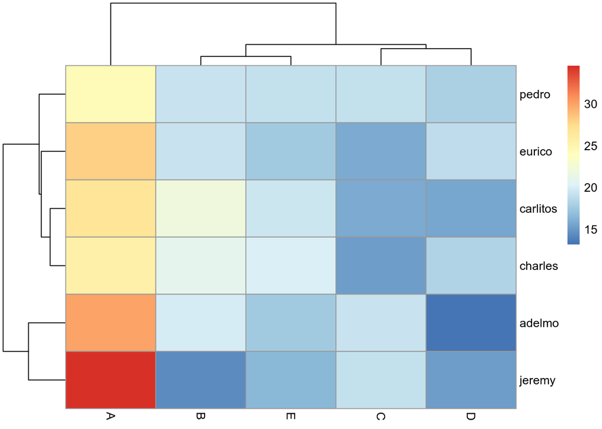

```r
library(pheatmap)

pt<-prop.table(table(set3$user_name,set3$classe),1)*100
pheatmap(pt)
```

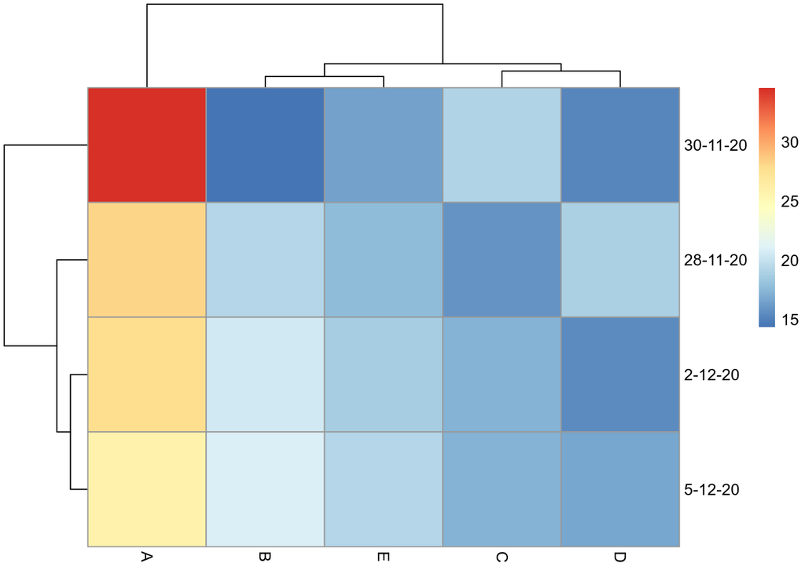

```r
pt<-prop.table(table(set3$cvtd_timestamp,set3$classe),1)*100
pheatmap(pt)
```

*Notice

Very few pepole (n=6) were tested in this study, in relatively short period of time (few days).  
Therefore, if we will include the user_name or other variable related to the timestamp in the model, the model will "memorize" the name of that person (or the time did the tests) and will asign the classification accordingly.  
As a result, I will filter-out these variables (user_name, raw_timestamp_part_1, raw_timestamp_part_2, cvtd_timestamp) from down-stream analysis.  
######################################

3. Use featureplot as density in order to see how each variable explain the `classe`.

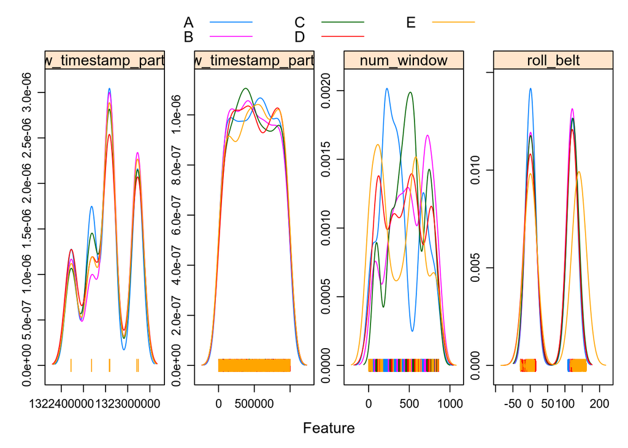

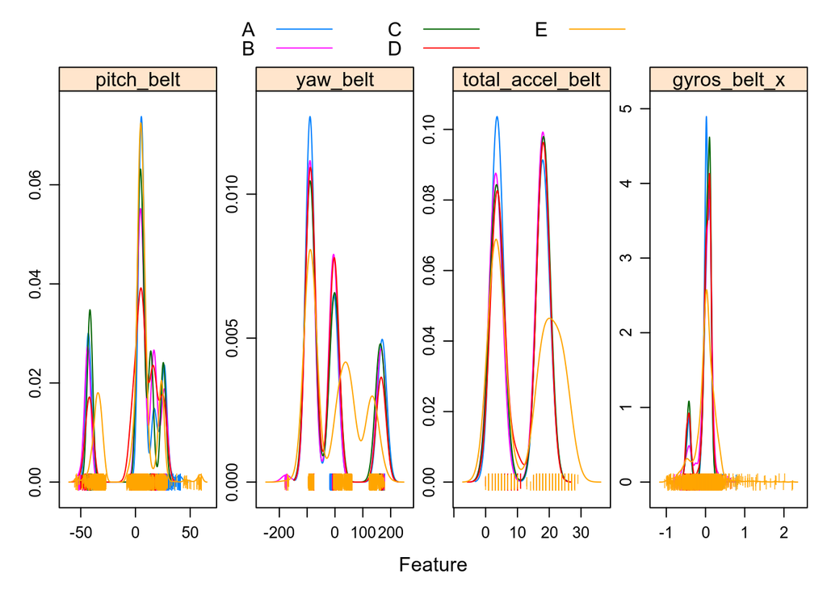

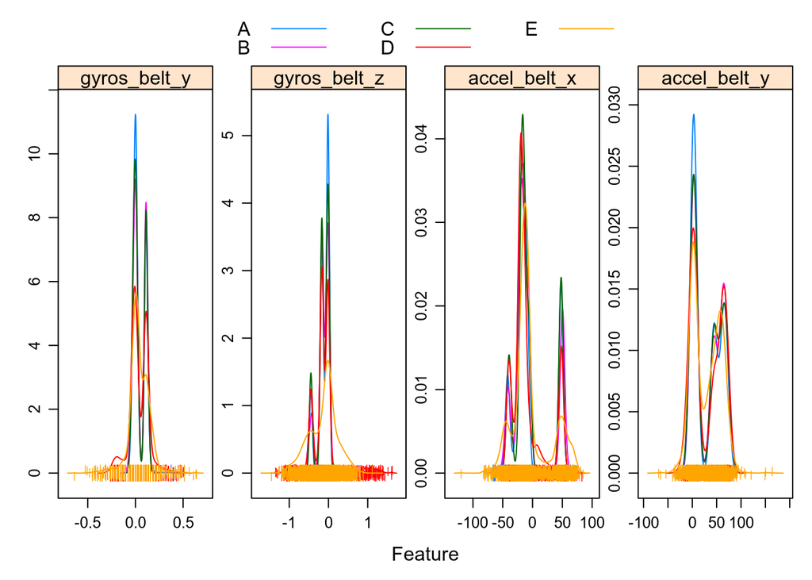

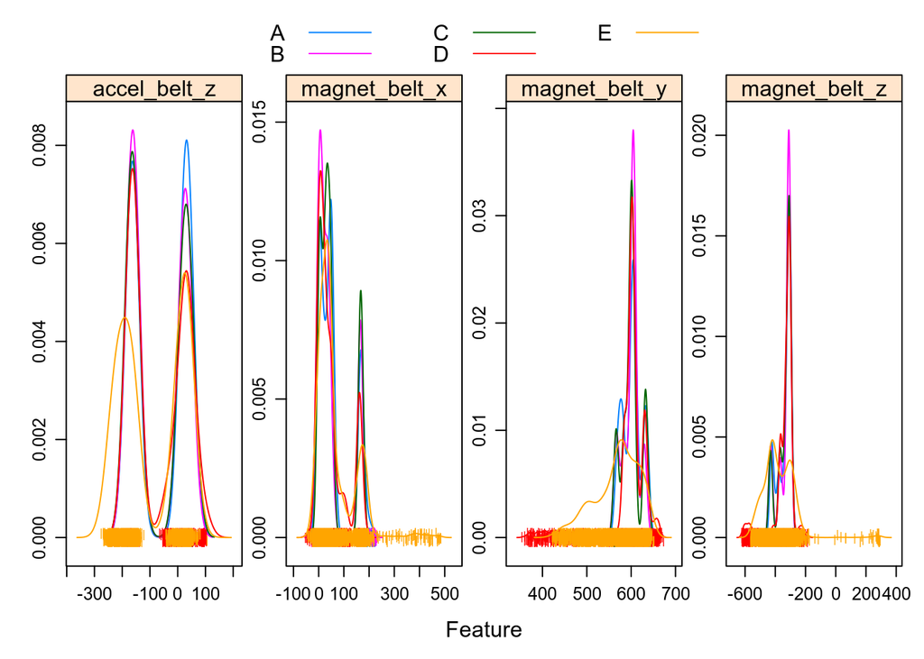

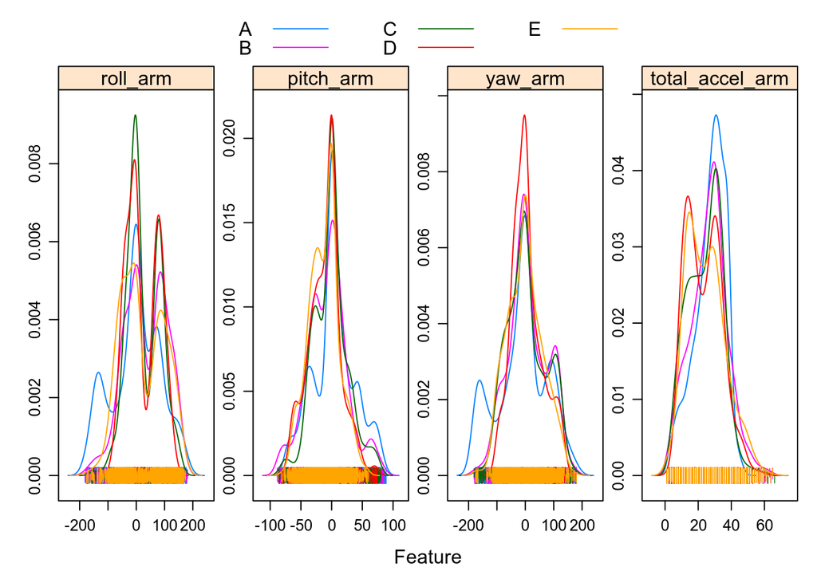

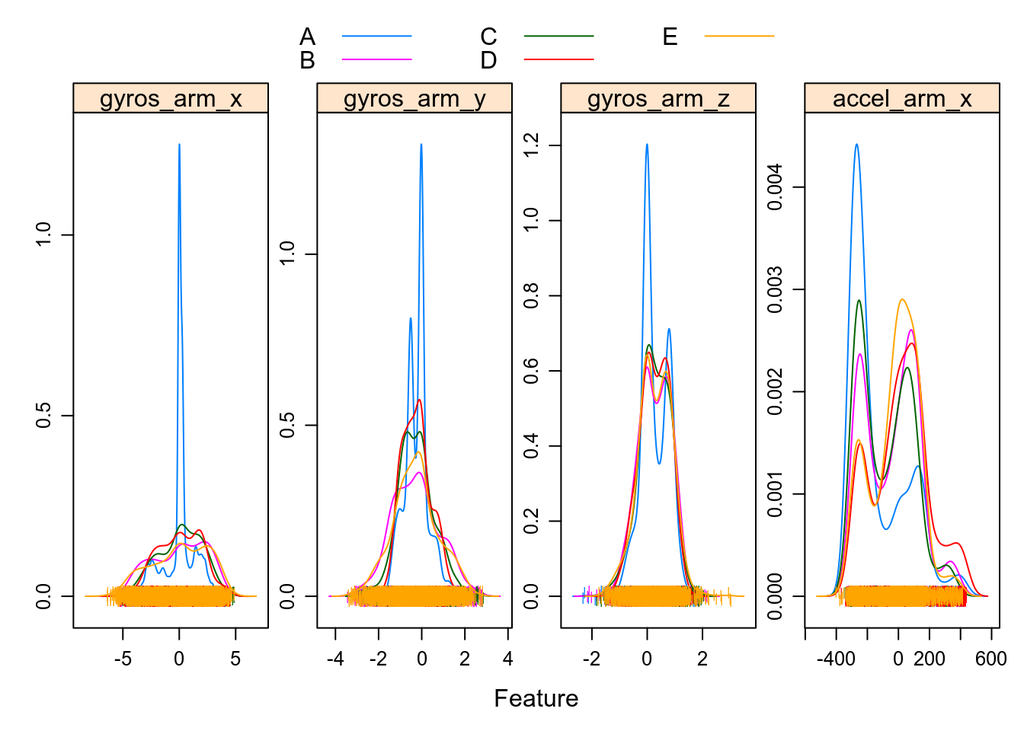

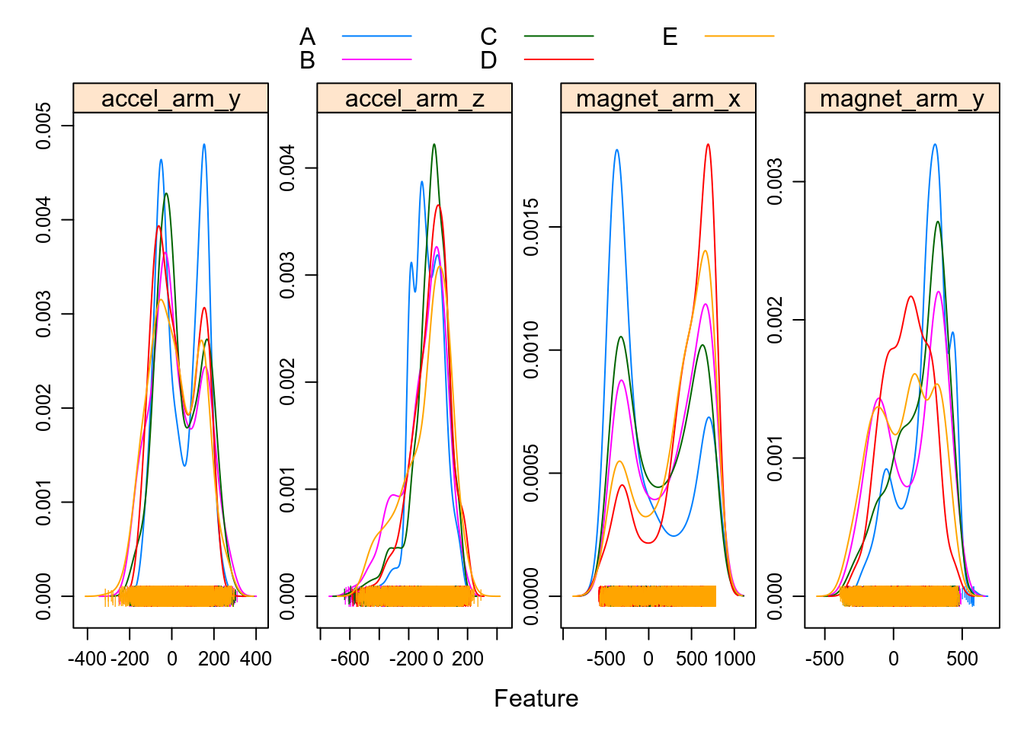

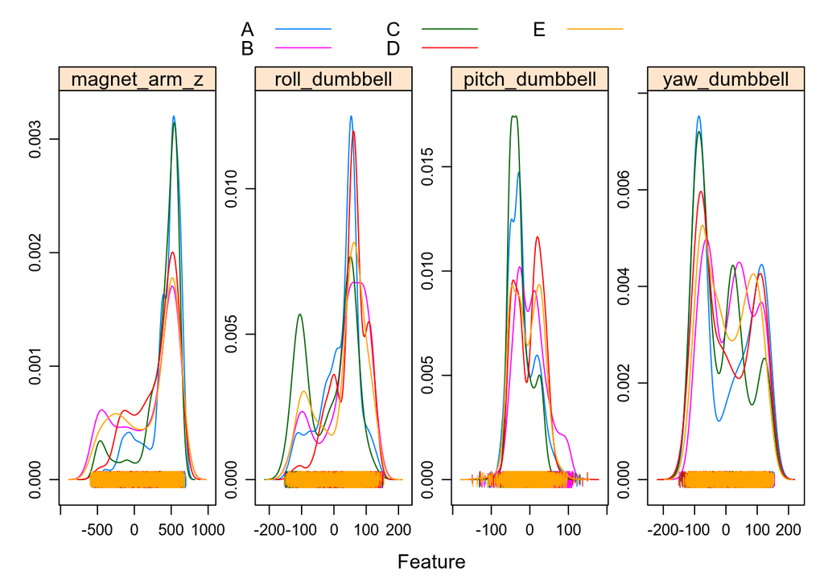

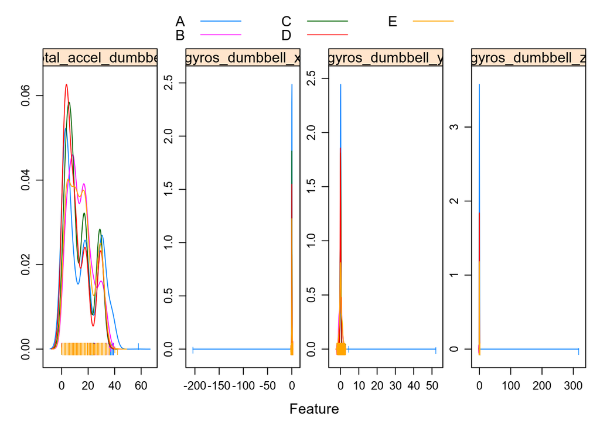

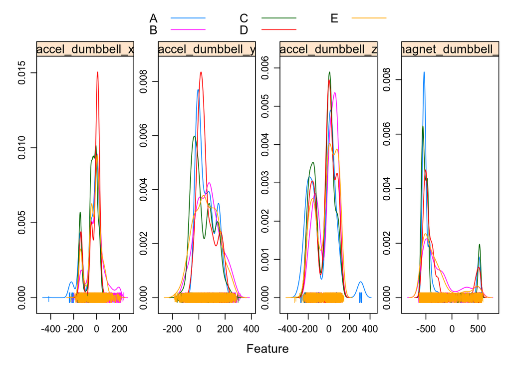

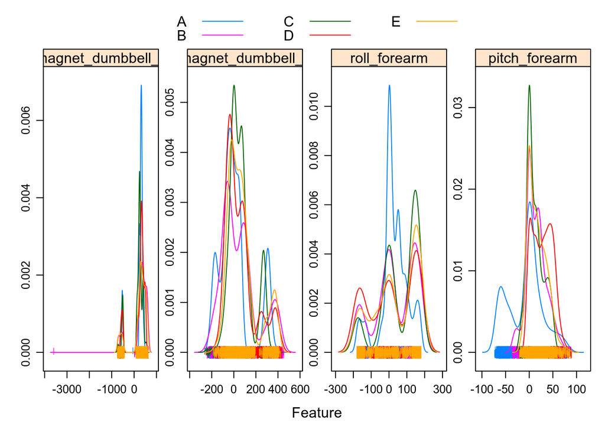

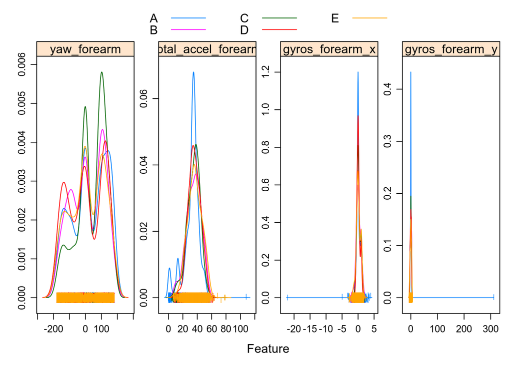

[2 more figures not shown]

```r
get_numeric<-function(a,mat){
  v<-NA;
  if(as.character(a)%in%colnames(mat)){
    if(is.numeric(mat[,as.character(a)])){
      v<-as.character(a);
    }else{
      v<-NA;
    }
  }
  return(v);
}

vars<-names(na.omit(sapply(colnames(set3[,colnames(set3)!="classe"]),get_numeric,set3)))


featurePlot(x = set3[,vars],
            y = factor(set3$classe),
            plot = "density",
            ## Pass in options to xyplot() to
            ## make it prettier
            scales = list(x = list(relation="free"),
                          y = list(relation="free")),
            adjust = 1.5,
            pch = "|",
            layout = c(4, 1),
            auto.key = list(columns = 3))
```

```r
# featurePlot(x = set3[,vars],
#             y = factor(set3$classe),
#             plot = "box",
#             ## Pass in options to bwplot()
#             scales = list(y = list(relation="free"),
#                           x = list(rot = 90)),
#             layout = c(4,1 ),
#             auto.key = list(columns = 2))
```

**Create train/test partition**

```r
library(caret)
set.seed(1234);

## filtering out the variables that are related to the name of the tested person or the time he did the tests##

set3<-set3[,!(colnames(set3)%in%c("user_name","raw_timestamp_part_1","raw_timestamp_part_2","cvtd_timestamp"))]

inTrain<-createDataPartition(set3$classe,p=0.6,list=F)


training<-set3[inTrain,]
testing<-set3[!(rownames(set3)%in%inTrain),];


###########################
#inTrain2<-createDataPartition(training0$classe,p=0.6,list=F)
#training<-training0[inTrain2,]
#testing<-training0[-inTrain2,]
####################################
#users<-unique(training$user_name)

count_NA<-function(v){
  k=0;
  for(i in 1:length(v)){
    if(is.na(v[i])){
      k=k+1;
    }
  }

  return(k);
}

val<-apply(training,2, count_NA);
#
len<-nrow(training)
col_to_ignore<-names(val[val>len*0.9])

training2<-training[,!(colnames(training)%in%col_to_ignore)]
testing2<-testing[,!(colnames(testing)%in%col_to_ignore)]



ctrl2 = trainControl(method = "repeatedcv",                                       repeats = 5,classProbs = TRUE, savePredictions = TRUE) ##, summaryFunction = twoClassSummary


colnames(training2)
```

```
##  [1] "new_window"           "num_window"           "roll_belt"
##  [4] "pitch_belt"           "yaw_belt"             "total_accel_belt"
##  [7] "gyros_belt_x"         "gyros_belt_y"         "gyros_belt_z"
## [10] "accel_belt_x"         "accel_belt_y"         "accel_belt_z"
## [13] "magnet_belt_x"        "magnet_belt_y"        "magnet_belt_z"
## [16] "roll_arm"             "pitch_arm"            "yaw_arm"
## [19] "total_accel_arm"      "gyros_arm_x"          "gyros_arm_y"
## [22] "gyros_arm_z"          "accel_arm_x"          "accel_arm_y"
## [25] "accel_arm_z"          "magnet_arm_x"         "magnet_arm_y"
## [28] "magnet_arm_z"         "roll_dumbbell"        "pitch_dumbbell"
## [31] "yaw_dumbbell"         "total_accel_dumbbell" "gyros_dumbbell_x"
## [34] "gyros_dumbbell_y"     "gyros_dumbbell_z"     "accel_dumbbell_x"
## [37] "accel_dumbbell_y"     "accel_dumbbell_z"     "magnet_dumbbell_x"
## [40] "magnet_dumbbell_y"    "magnet_dumbbell_z"    "roll_forearm"
## [43] "pitch_forearm"        "yaw_forearm"          "total_accel_forearm"
## [46] "gyros_forearm_x"      "gyros_forearm_y"      "gyros_forearm_z"
## [49] "accel_forearm_x"      "accel_forearm_y"      "accel_forearm_z"
## [52] "magnet_forearm_x"     "magnet_forearm_y"     "magnet_forearm_z"
## [55] "classe"
```

```r
training2$classe<-factor(training2$classe);
testing2$classe<-factor(testing2$classe);


library(doParallel)
cl <- makePSOCKcluster(6)
registerDoParallel(cl)
```

Prints variableImportace using randomForset model

```r
library(randomForest)
model<-randomForest(x=training2[,colnames(training2)!="classe"],y=training2$classe,mtry=20,ntree=50)


(vv<-varImp(model))
```

```
##                           Overall
## new_window              0.3379855
## num_window           1268.2261866
## roll_belt             958.6002509
## pitch_belt            403.5637316
## yaw_belt              575.8421170
## total_accel_belt       80.4949310
## gyros_belt_x           35.3295198
## gyros_belt_y           45.9737307
## gyros_belt_z          134.1946124
## accel_belt_x           36.3760936
## accel_belt_y           45.4992917
## accel_belt_z          198.3549779
## magnet_belt_x         109.2172971
## magnet_belt_y         143.2492665
## magnet_belt_z         141.3440119
## roll_arm              114.2949339
## pitch_arm              66.0670688
## yaw_arm                86.2908367
## total_accel_arm        24.4975477
## gyros_arm_x            46.9085081
## gyros_arm_y            48.5058019
## gyros_arm_z            17.6749790
## accel_arm_x            96.4589474
## accel_arm_y            51.1970408
## accel_arm_z            59.1501941
## magnet_arm_x          129.6778657
## magnet_arm_y           86.0908887
## magnet_arm_z           53.8256521
## roll_dumbbell         194.7130493
## pitch_dumbbell         53.1708415
## yaw_dumbbell          102.6251318
## total_accel_dumbbell  143.0588817
## gyros_dumbbell_x       35.9439678
## gyros_dumbbell_y      107.8188897
## gyros_dumbbell_z       26.2343817
## accel_dumbbell_x      106.8911023
## accel_dumbbell_y      228.5399340
## accel_dumbbell_z      165.9547827
## magnet_dumbbell_x     221.5272180
## magnet_dumbbell_y     469.0920060
## magnet_dumbbell_z     489.7484789
## roll_forearm          412.8996655
## pitch_forearm         607.7280945
## yaw_forearm            80.4541268
## total_accel_forearm    34.2734390
## gyros_forearm_x        25.1772563
## gyros_forearm_y        40.2758659
## gyros_forearm_z        29.5082021
## accel_forearm_x       220.6365682
## accel_forearm_y        47.8504350
## accel_forearm_z       107.1890237
## magnet_forearm_x       61.0234069
## magnet_forearm_y       75.4070917
## magnet_forearm_z      163.9507614
```

```r
pred<-predict(model,newdata=testing2)
```

- It seems that the highest importance has for 'num_window' and 'roll_belt'

Testing confusion matrix, with randomForset model

```r
(t<-table(pred,testing2$classe))
```

```
##
## pred    A    B    C    D    E
##    A 2232    4    0    0    0
##    B    0 1512    1    0    0
##    C    0    2 1365    5    0
##    D    0    0    2 1280    4
##    E    0    0    0    1 1438
```

```r
train_acc<-mean(model$predicted==training2$classe)
test_acc<-mean(pred==testing2$classe)
cat("Testing accuracy:\t",test_acc,"\n");
```

```
## Testing accuracy:     0.9975784
```

```r
cat("Training accuracy:\t",train_acc,"\n");
```

```
## Training accuracy:    0.9954144
```

```r
#plot(vv)
```

Plot densities of randomForset prediction using trainging and testing data  
##########################

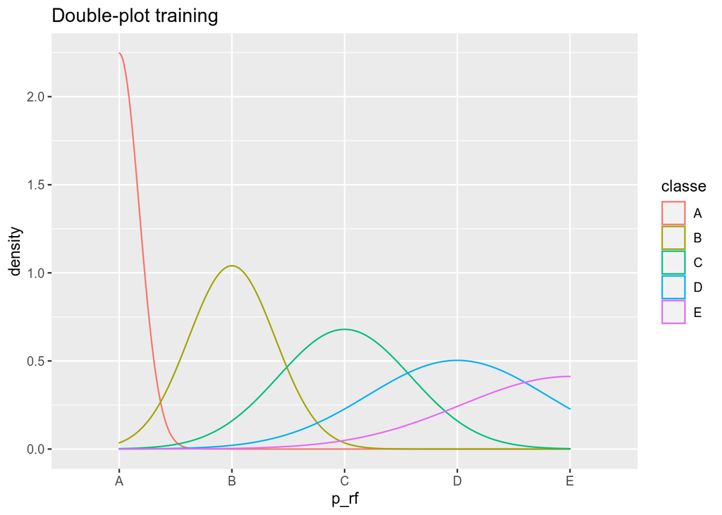

```r
pred_rf0<-predict(model,newdata=training2)
pred_rf1<-predict(model,newdata=testing2)

df1<-data.frame(p_rf=pred_rf1,classe=testing2$classe);
df0<-data.frame(p_rf=pred_rf0,classe=training2$classe);

ggplot(df0, aes(x=p_rf, color=classe)) + geom_density()+ggtitle("Double-plot training")
```

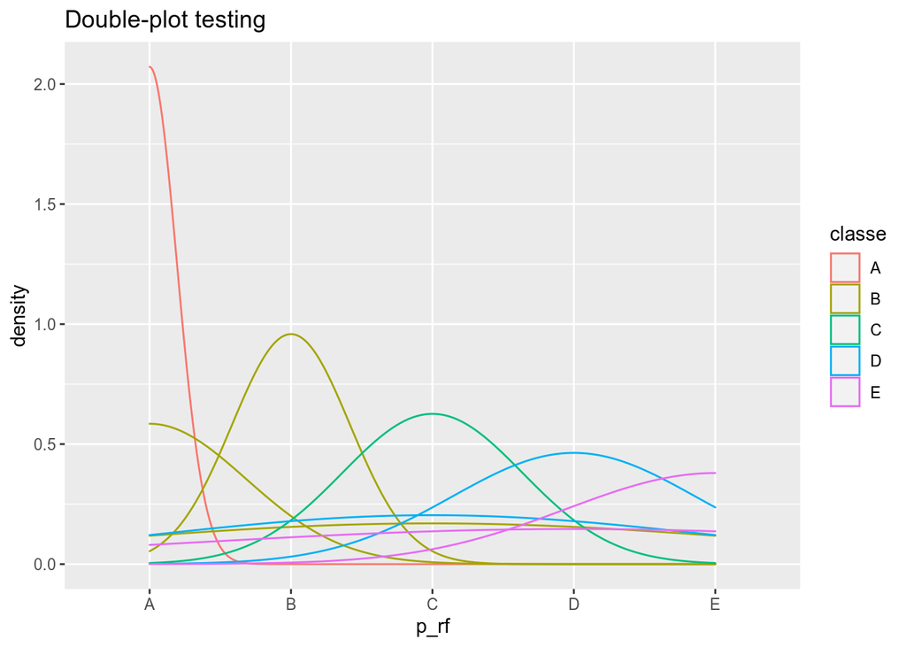

```r
ggplot(df1, aes(x=p_rf, color=classe)) + geom_density()+ggtitle("Double-plot testing")
```

- Of course, prediction based on training data is exgrading.  
  Using testing data is the realistic calculation.  
  #####################################################

Fit RandomForset, GBM and SVM for classification  
########################################################

```r
#fit<-train((classe) ~ . ,data=head(training2,100),method="rf")
library("gbm")
library("randomForest")
library("e1071")
fit_svm<-svm(classe ~. ,data=training2,kernel="radial")

fit_rf<-randomForest(classe ~. ,data=training2,mtry=20,ntree=1000)

fit_gbm<-gbm(classe ~. ,data=training2)
```

```
## Distribution not specified, assuming multinomial ...
```

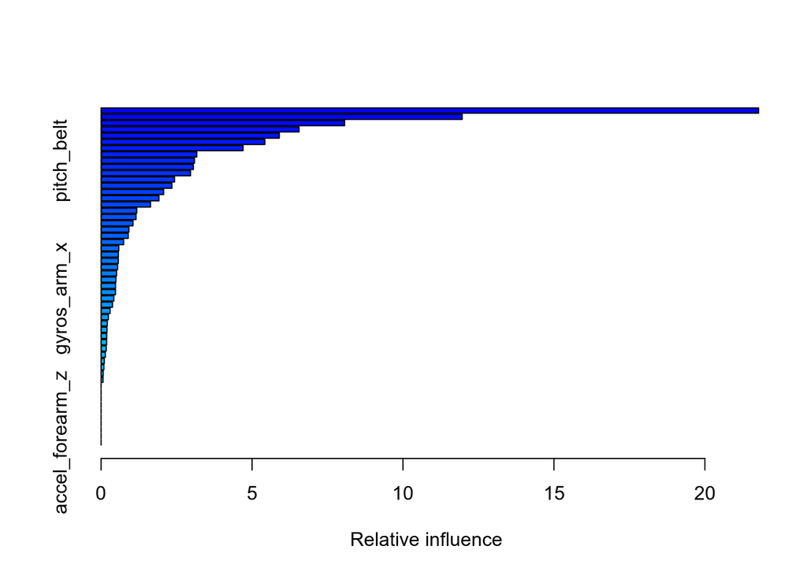

```
##                                       var     rel.inf
## roll_belt                       roll_belt 21.77881441
## pitch_forearm               pitch_forearm 11.96007261
## num_window                     num_window  8.06659171
## magnet_dumbbell_y       magnet_dumbbell_y  6.55707217
## yaw_belt                         yaw_belt  5.90223330
## magnet_dumbbell_z       magnet_dumbbell_z  5.42385410
## roll_forearm                 roll_forearm  4.70213711
## magnet_belt_z               magnet_belt_z  3.16888350
## pitch_belt                     pitch_belt  3.09187050
## gyros_dumbbell_y         gyros_dumbbell_y  3.05540293
## gyros_belt_z                 gyros_belt_z  2.96272900
## accel_forearm_x           accel_forearm_x  2.43211633
## roll_dumbbell               roll_dumbbell  2.34588712
## magnet_arm_x                 magnet_arm_x  2.07170014
## accel_dumbbell_y         accel_dumbbell_y  1.91588403
## magnet_arm_z                 magnet_arm_z  1.63702498
## yaw_arm                           yaw_arm  1.17906287
## magnet_forearm_z         magnet_forearm_z  1.15555598
## accel_dumbbell_x         accel_dumbbell_x  1.05598795
## magnet_dumbbell_x       magnet_dumbbell_x  0.92069444
## gyros_arm_y                   gyros_arm_y  0.89816641
## pitch_dumbbell             pitch_dumbbell  0.74513653
## accel_belt_z                 accel_belt_z  0.58570946
## accel_dumbbell_z         accel_dumbbell_z  0.57223307
## magnet_arm_y                 magnet_arm_y  0.57018428
## gyros_belt_y                 gyros_belt_y  0.54738093
## magnet_forearm_x         magnet_forearm_x  0.51106484
## total_accel_dumbbell total_accel_dumbbell  0.48976478
## magnet_belt_y               magnet_belt_y  0.47779916
## roll_arm                         roll_arm  0.47760432
## gyros_arm_x                   gyros_arm_x  0.42161705
## magnet_forearm_y         magnet_forearm_y  0.37653507
## total_accel_forearm   total_accel_forearm  0.29744597
## gyros_dumbbell_x         gyros_dumbbell_x  0.23966547
## gyros_forearm_y           gyros_forearm_y  0.20396503
## gyros_dumbbell_z         gyros_dumbbell_z  0.19521546
## accel_arm_x                   accel_arm_x  0.18645804
## gyros_forearm_z           gyros_forearm_z  0.18288161
## magnet_belt_x               magnet_belt_x  0.16913212
## accel_arm_z                   accel_arm_z  0.14124949
## gyros_forearm_x           gyros_forearm_x  0.10511822
## yaw_dumbbell                 yaw_dumbbell  0.09144384
## accel_belt_x                 accel_belt_x  0.06773705
## gyros_belt_x                 gyros_belt_x  0.06291664
## new_window                     new_window  0.00000000
## total_accel_belt         total_accel_belt  0.00000000
## accel_belt_y                 accel_belt_y  0.00000000
## pitch_arm                       pitch_arm  0.00000000
## total_accel_arm           total_accel_arm  0.00000000
## gyros_arm_z                   gyros_arm_z  0.00000000
## accel_arm_y                   accel_arm_y  0.00000000
## yaw_forearm                   yaw_forearm  0.00000000
## accel_forearm_y           accel_forearm_y  0.00000000
## accel_forearm_z           accel_forearm_z  0.00000000
```

```r
summary(fit_gbm)
```

- Using GBM the 3 most influancial variable are: roll_belt, pitch_forearm and num_window.

Evaluate preformance based on testing2 data

```r
pred_rf<-predict(fit_rf,newdata=testing2);
pred_svm<-predict(fit_svm,newdata=testing2)
pred_gbm0<-predict(fit_gbm,newdata=testing2,type="response")
```

```
## Using 100 trees...
```

```r
pred_gbm <- as.factor(colnames(pred_gbm0)[apply(pred_gbm0, 1, which.max)])
```

Print preformace values using confusionMatrix  
1. RandomForset  
2. SVM  
3. GBM  
######################################

```r
confusionMatrix(pred_rf,testing2$classe)
```

```
## Confusion Matrix and Statistics
##
##           Reference
## Prediction    A    B    C    D    E
##          A 2232    4    0    0    0
##          B    0 1514    2    0    0
##          C    0    0 1366    4    0
##          D    0    0    0 1282    3
##          E    0    0    0    0 1439
##
## Overall Statistics
##
##                Accuracy : 0.9983
##                  95% CI : (0.9972, 0.9991)
##     No Information Rate : 0.2845
##     P-Value [Acc > NIR] : < 2.2e-16
##
##                   Kappa : 0.9979
##
##  Mcnemar's Test P-Value : NA
##
## Statistics by Class:
##
##                      Class: A Class: B Class: C Class: D Class: E
## Sensitivity            1.0000   0.9974   0.9985   0.9969   0.9979
## Specificity            0.9993   0.9997   0.9994   0.9995   1.0000
## Pos Pred Value         0.9982   0.9987   0.9971   0.9977   1.0000
## Neg Pred Value         1.0000   0.9994   0.9997   0.9994   0.9995
## Prevalence             0.2845   0.1935   0.1744   0.1639   0.1838
## Detection Rate         0.2845   0.1930   0.1741   0.1634   0.1834
## Detection Prevalence   0.2850   0.1932   0.1746   0.1638   0.1834
## Balanced Accuracy      0.9996   0.9985   0.9990   0.9982   0.9990
```

```r
confusionMatrix(pred_svm,testing2$classe)
```

```
## Confusion Matrix and Statistics
##
##           Reference
## Prediction    A    B    C    D    E
##          A 2200  103    3    0    3
##          B    6 1366   56    3    1
##          C   22   41 1290  119   24
##          D    1    1   18 1164   51
##          E    3    7    1    0 1363
##
## Overall Statistics
##
##                Accuracy : 0.941
##                  95% CI : (0.9355, 0.9461)
##     No Information Rate : 0.2845
##     P-Value [Acc > NIR] : < 2.2e-16
##
##                   Kappa : 0.9253
##
##  Mcnemar's Test P-Value : < 2.2e-16
##
## Statistics by Class:
##
##                      Class: A Class: B Class: C Class: D Class: E
## Sensitivity            0.9857   0.8999   0.9430   0.9051   0.9452
## Specificity            0.9806   0.9896   0.9682   0.9892   0.9983
## Pos Pred Value         0.9528   0.9539   0.8623   0.9425   0.9920
## Neg Pred Value         0.9942   0.9763   0.9877   0.9815   0.9878
## Prevalence             0.2845   0.1935   0.1744   0.1639   0.1838
## Detection Rate         0.2804   0.1741   0.1644   0.1484   0.1737
## Detection Prevalence   0.2943   0.1825   0.1907   0.1574   0.1751
## Balanced Accuracy      0.9831   0.9447   0.9556   0.9472   0.9717
```

```r
confusionMatrix(pred_gbm,testing2$classe)
```

```
## Confusion Matrix and Statistics
##
##           Reference
## Prediction    A    B    C    D    E
##          A 1961  164   27   56   45
##          B   64 1133   83   38   79
##          C   45  154 1226  144   73
##          D  140   63   30 1004   59
##          E   22    4    2   44 1186
##
## Overall Statistics
##
##                Accuracy : 0.8297
##                  95% CI : (0.8212, 0.838)
##     No Information Rate : 0.2845
##     P-Value [Acc > NIR] : < 2.2e-16
##
##                   Kappa : 0.7847
##
##  Mcnemar's Test P-Value : < 2.2e-16
##
## Statistics by Class:
##
##                      Class: A Class: B Class: C Class: D Class: E
## Sensitivity            0.8786   0.7464   0.8962   0.7807   0.8225
## Specificity            0.9480   0.9583   0.9358   0.9555   0.9888
## Pos Pred Value         0.8704   0.8110   0.7467   0.7747   0.9428
## Neg Pred Value         0.9515   0.9403   0.9771   0.9569   0.9611
## Prevalence             0.2845   0.1935   0.1744   0.1639   0.1838
## Detection Rate         0.2499   0.1444   0.1563   0.1280   0.1512
## Detection Prevalence   0.2872   0.1781   0.2093   0.1652   0.1603
## Balanced Accuracy      0.9133   0.8523   0.9160   0.8681   0.9056
```

**Use majority vote classification**

In order to better generlize even for examples that were not included in the training set (as the examples were taken from very few pepole in this study), I will use majority vote between 3 methods: randomForset, GBM, and SVM in order to predict in the next step an unseen example.  
########################################

```r
pred_final<-data.frame(cbind(as.character(pred_rf),as.character(pred_gbm),as.character(pred_svm)),check.names = F)


get_majority_vote<-function(vec){
  v<-c(0,0,0,0,0);
  for(i in 1:length(vec)){
    if(vec[i]=="A"){
      v[1]=v[1]+1;
    }
    if(vec[i]=="B"){
      v[2]=v[2]+1;
    }
    if(vec[i]=="C"){
      v[3]=v[3]+1;
    }
    if(vec[i]=="D"){
      v[4]=v[4]+1;
    }
    if(vec[i]=="E"){
      v[5]=v[5]+1;
    }
  }

  max_m<-max(v);

  if(v[1]==max_m){
    return("A");
  }

  if(v[2]==max_m){
    return("B");
  }
  if(v[3]==max_m){
    return("C");
  }
  if(v[4]==max_m){
    return("D");
  }
  if(v[5]==max_m){
    return("E");
  }

}

pred_final$majority<-apply(pred_final[,1:3],1,get_majority_vote)

##
ACC_testing<-c()
#
ACC_testing[1]<-mean(testing2$classe==pred_final$majority)
ACC_testing[2]<-mean(testing2$classe==pred_rf)
ACC_testing[3]<-mean(testing2$classe==pred_svm)
ACC_testing[4]<-mean(testing2$classe==pred_gbm)


names(ACC_testing)<-c("Majority_Vote","RF","SVM","GBM");

A_testing <- data.frame(
  name= names(ACC_testing),
  value=ACC_testing
  )
```

Plot the predicted accuracy useing the majority voting vs. RF/GBM/SVM  
######################################

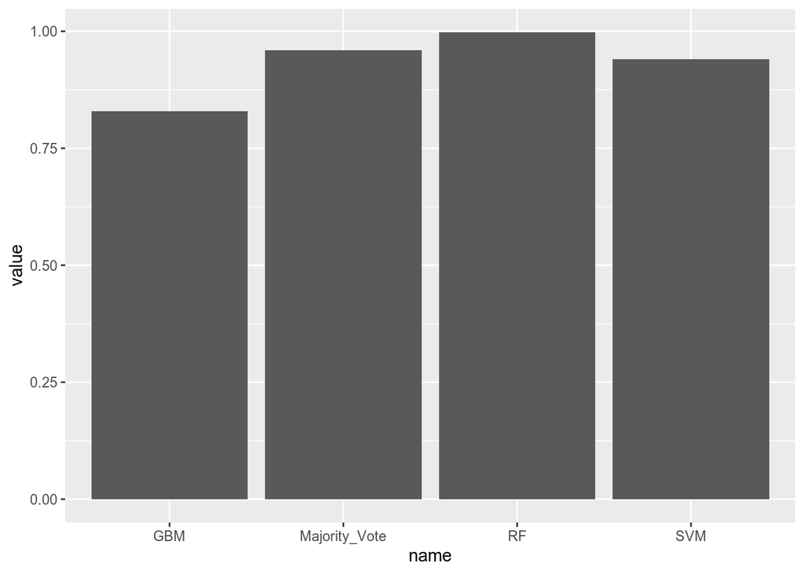

```r
ggplot(A_testing, aes(x=name, y=value)) +
  geom_bar(stat = "identity")
```

```r
#####################################################
```

**Predict an unseen example**  
###########################################

```r
valid<-read.csv("/home/oz/Downloads/pml-testing.csv",header=T,row.names = 1)
# valid$classe<-factor("A",levels=c("A","B","C","D","E"))
# valid<-valid[,colnames(training2)]
valid$new_window<-factor(valid$new_window,levels=c("yes","no"))
pred2<-predict(fit_rf,newdata=valid)
pred3_0<-predict(fit_gbm,newdata=valid,type="response")
```

```
## Using 100 trees...
```

```r
pred3<-as.factor(colnames(pred3_0)[apply(pred3_0, 1, which.max)])


var_s<-colnames(testing2[,colnames(testing2)!="classe"])
v<-valid[,var_s]
pred4<-predict(fit_svm,newdata=v)


valid_pred<-data.frame(cbind(as.character(pred2),as.character(pred3),as.character(pred4)),check.names = F)
valid_pred$majority<-apply(valid_pred[,1:3],1,get_majority_vote);
colnames(valid_pred)<-c("RF","GBM","SVM","majority")
table(valid_pred$majority)
```

```
##
## A B C D E
## 8 7 1 1 3
```

```r
#####################################
stopCluster(cl)
```